# HW4

Yu-Xiang, Lin

2020/11/8

```r
library(tidyverse)
library(glmnet)
```

# Analyze all the spam data using variable selection methods including (a) forward stepwise regression and backward stepwise regression. (12%) (b) Randomly select two thirds of the data as the training dataset and the remaining one third as the test data. (set.seed(1001)) (i) Use the training data to identify the lambda value that gives minimum cross-validated error for lasso regression, ridge regression, and elastic net regression with different alpha values. (20%) (ii) Apply the lambda with minimum cross-validated error to the test data and evaluate their mean square errors. (20%)

## (a)

```r
p1 <- read.table("/Users/linyuxiang/R/MSA/Data/spam.dat", header = T)
p1.fwd <- step(lm(Y ~ 1, data=p1),~X.1+X.2+X.3+X.4+X.5+X.6+X.7+X.8+X.9+X.10+X.11+X.12+X.13+X.14+X.15+X.16+X.17+X.18+X.19+X.20+X.21+X.22+X.23+X.24+X.25+X.26+X.27+X.28+X.29+X.30+X.31+X.32+X.33+X.34+X.35+X.36+X.37+X.38+X.39+X.40+X.41+X.42+X.43+X.44+X.45+X.46+X.47+X.48+X.49+X.50+X.51+X.52+X.53+X.54+X.55+X.56+X.57, data=p1, direction="forward")
fw_res <- p1.fwd$model %>% names()
# backward
p1.lrs <- lm(Y~., data = p1)
pr.bwd <- step(p1.lrs, direction = "backward")
bw_res <- pr.bwd %>% names()
```

```r
intersect(fw_res, bw_res)
```

```
## character(0)
```

```r
setdiff(fw_res, bw_res)
```

```
##  [1] "Y"    "X.21" "X.23" "X.7"  "X.57" "X.16" "X.52" "X.25" "X.5"  "X.53"
## [11] "X.8"  "X.24" "X.6"  "X.20" "X.22" "X.42" "X.18" "X.27" "X.46" "X.49"
## [21] "X.45" "X.19" "X.33" "X.9"  "X.26" "X.12" "X.17" "X.37" "X.44" "X.3"
## [31] "X.4"  "X.48" "X.47" "X.43" "X.1"  "X.2"  "X.35" "X.55" "X.40" "X.30"
## [41] "X.11" "X.54" "X.38" "X.10" "X.50" "X.56" "X.34" "X.39"
```

```r
setdiff(bw_res, fw_res)
```

```
##  [1] "coefficients"  "residuals"     "effects"       "rank"
##  [5] "fitted.values" "assign"        "qr"            "df.residual"
##  [9] "xlevels"       "call"          "terms"         "model"
## [13] "anova"
```

## (b)

```r
set.seed(1001)
indx <- sample(1:nrow(p1) ,nrow(p1)*.67)
train.p1 <- p1[indx,]
test.p1 <- p1[-indx,]
nrow(train.p1)+nrow(test.p1) == nrow(p1)
```

```
## [1] TRUE
```

```r
df <- data_frame(alpha = rep(NA,11), MSE = NA)
for (i in 0:10){
cv_fit <-  cv.glmnet(train.p1[,-58] %>% as.matrix, train.p1[,58] %>% as.matrix, type.measure="mse", alpha=i/10,family="gaussian")

fit <- glmnet(train.p1[,-58] %>% as.matrix, train.p1[,58] %>% as.matrix, family="binomial", alpha=1, lambda = cv_fit$lambda.min)

fit_pred <- predict(fit, newx = test.p1[,-58] %>% as.matrix)
# MSE lasso
df$MSE[i+1] <- sum((fit_pred - test.p1$Y)^2) / nrow(fit_pred)
df$alpha[i+1] <- (i/10)
message(i)
}
```

```
## 0
```

```
## 1
```

```
## 2
```

```
## 3
```

```
## 4
```

```
## 5
```

```
## 6
```

```
## 7
```

```
## 8
```

```
## 9
```

```
## 10
```

```r
df$label[1] <- "Ridge"
```

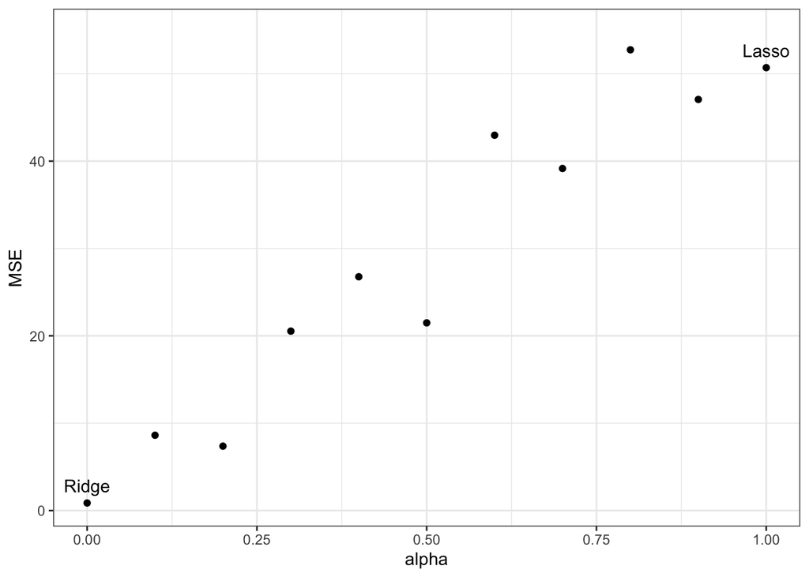

```r
df$label[2:10] <- NA
df$label[11] <- "Lasso"
df %>%
  ggplot(aes(x = alpha, y = MSE))+
  geom_point()+
  geom_text(aes(label = label, y = MSE+2))+
  theme_bw()
```

# Problem 2

Carry out a principal component analysis on the engineer data as follows. Ignore groups and use a correlation matrix based on all 40 observations. (48%)(pilots.dat) Table. Comparison of Six Tests on Engineer Apprentices and Pilots

```r
p2 <- read.table("/Users/linyuxiang/R/MSA/Data/pilots.dat", header = F)

p2 <- p2[,-1]
eigen(cor(p2))
```

```
## eigen() decomposition
## $values
## [1] 1.7751277 1.3544159 1.0726505 0.8147958 0.5306128 0.4523973
##
## $vectors
##             [,1]       [,2]       [,3]       [,4]       [,5]       [,6]
## [1,] -0.40239072  0.3964661  0.4617841 -0.3928149 -0.2103062  0.5187674
## [2,]  0.09715877  0.7472294 -0.1752970 -0.1315611 -0.2801896 -0.5528697
## [3,] -0.38541311 -0.2181560 -0.4329575 -0.7177525  0.2585104 -0.1855163
## [4,] -0.54333623 -0.3144601 -0.1065065  0.2453920 -0.7066663 -0.1869825
## [5,]  0.31188931 -0.3559400  0.6268314 -0.3992852 -0.2012981 -0.4279773
## [6,] -0.53629229  0.1062657  0.4053555  0.3058981  0.5201339 -0.4155385
```

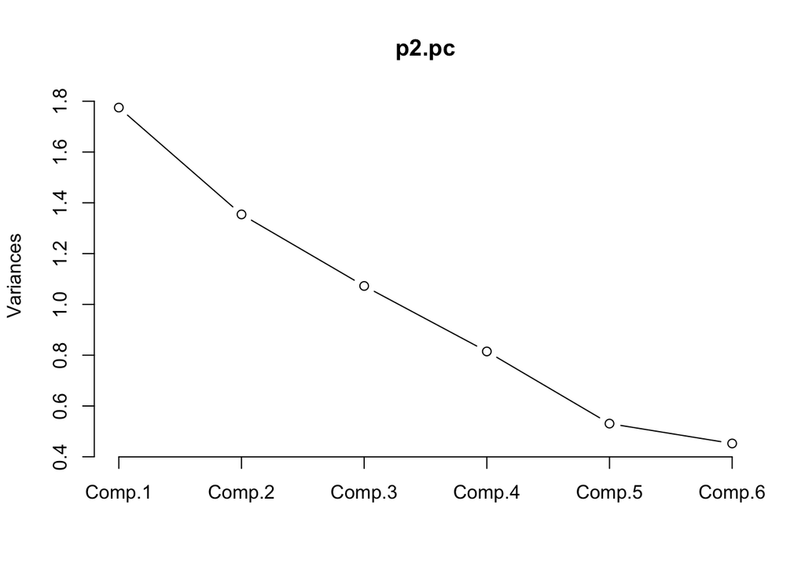

```r
p2.pc <- princomp(p2,cor=TRUE)
plot(p2.pc, type = "l")
```